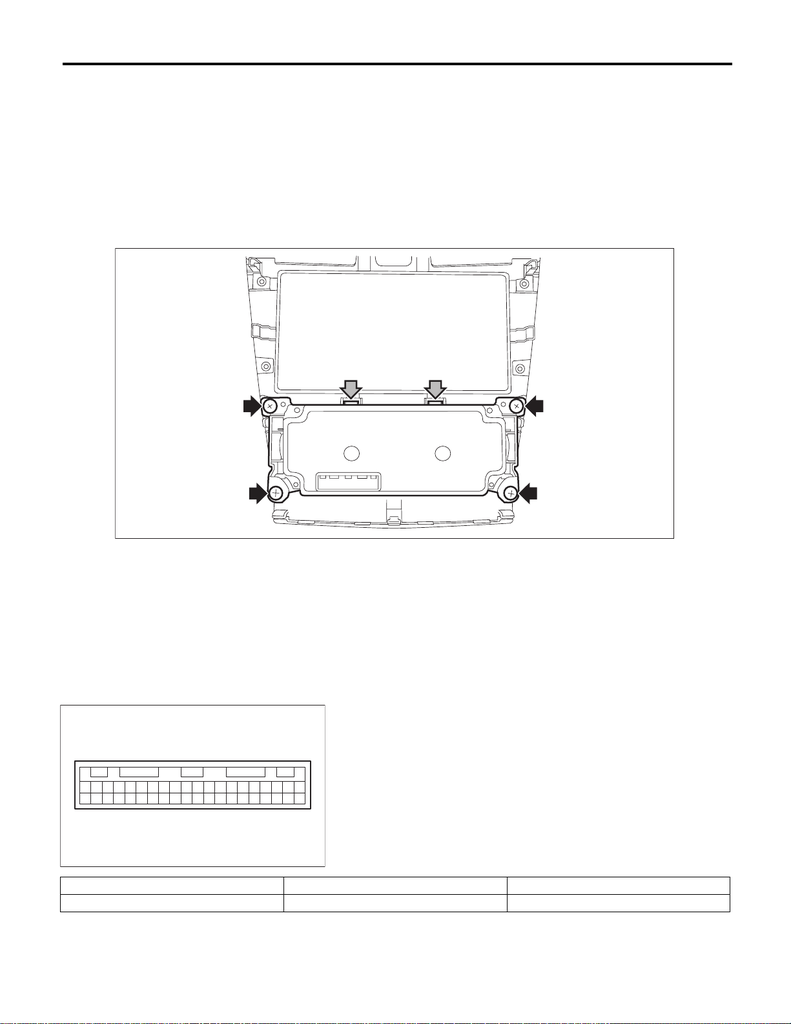

Control Panel

HVAC SYSTEM (HEATER, VENTILATOR AND A/C)

13.Control Panel

A: REMOVAL

1) Disconnect the ground cable from battery. <Ref. to NT-5, BATTERY, NOTE, Note.>

NOTE:

For models other than STI model, disconnect the ground terminal from battery sensor.

2) Remove the panel center assembly. <Ref. to EI-66, REMOVAL, Center Console.>

3) Remove the heater control assembly.

(1) Remove the screws.

(2) Release the claws, and remove the heater control assembly.

B: INSTALLATION

1) Install the heater control assembly.

2) Install the panel center assembly.

3) Connect the battery ground terminal. <Ref. to NT-5, BATTERY, NOTE, Note.>

NOTE:

For models other than STI model, connect the ground terminal to battery sensor.

C: INSPECTION

1) Check the illumination operation when battery voltage is applied between the connector terminals.

2) If it does not operate normally, replace the heater control assembly.

3

1

36

4

Terminal No. Inspection conditions Specification

37 (+) — 35 (–) Apply battery voltage. Light ON